# PSC4375: Interactions with Continuous Variables

Week 9: Lecture 13 (& 14)

Prof. Weldzius

Slides Updated: 2025-03-17

# Week 9

# Interactions with Continuous Variables

- Continuing with the Michigan **social pressure get-out-the-vote experiment**
- Create an age variable:

```r
data(social, package="qss")
social <- social %>%
  mutate(age = 2006 - yearofbirth)
summary(social$age)
```

```
##    Min. 1st Qu.  Median    Mean 3rd Qu.    Max.
##   20.00   41.00   50.00   49.79   59.00  106.00
```

# Hetergeneous effects

- From before:
  - Effect of the Neighbors mailer differ from previous voters vs. nonvoters?
  - Used an interaction term to assess **effect heterogeneity** between groups
- How does the effect of the Neighbors mailer vary by age?
  - Not just two groups, but a continuum of possible age values
- Remarkable, the same **interaction term** will work here too!

$$Y_i = \alpha + \beta_1\text{age}_i + \beta_2 \text{neighbors}_i +
\beta_3 (\text{age}_i \times \text{neighbors}_i) + \varepsilon_i$$

# Predicted values from non-interacted model

- Let $X_i =$ age$_i$ and $Z_i =$ neighbors$_i$

$$\hat{Y}_i = \hat{\alpha} + \hat{\beta}_1 X_i + \hat{\beta}_2 Z_i$$

# Visualizing the regression

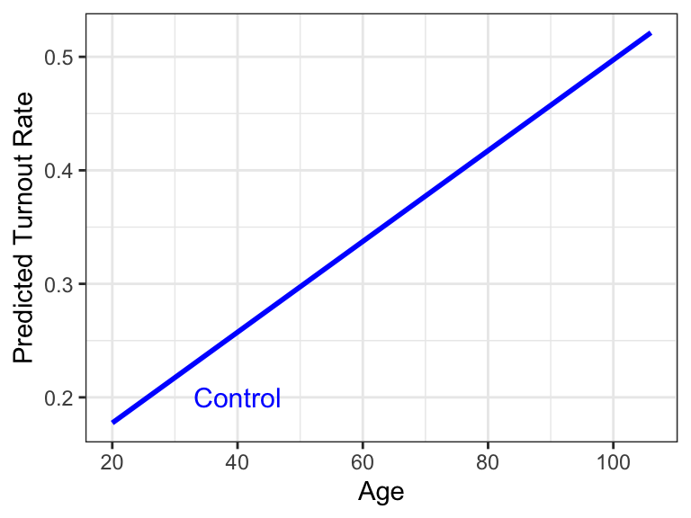

# Visualizing the regression

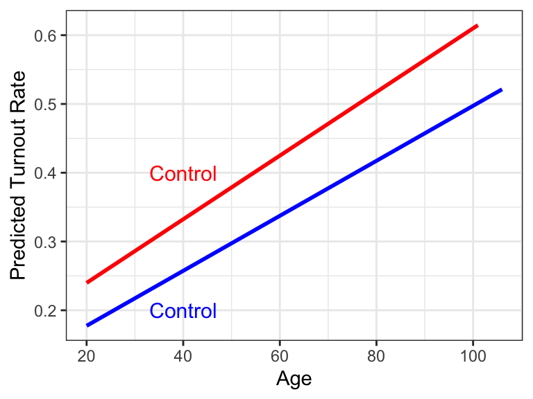

# Visualizing the regression

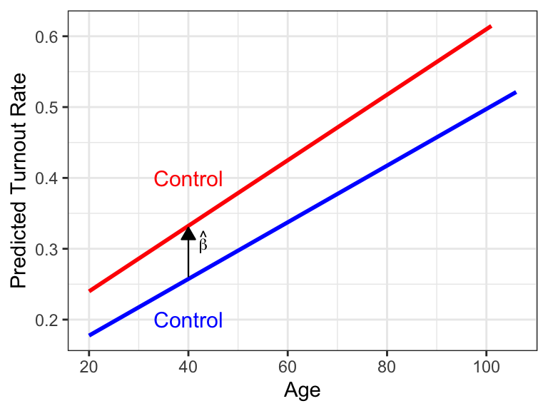

# Predicted values from interacted model

$$\hat{Y}_i = \hat{\alpha} + \hat{\beta}_1 X_i + \hat{\beta}_2 Z_i +
\hat{\beta}_3 X_i Z_i$$

- Effect of Neighbors for a 25 year-old:

$$(\hat{\alpha} + \hat{\beta}_1 25 + \hat{\beta}_2 + \hat{\beta}_3 25) -
(\hat{\alpha} + \hat{\beta}_1 25) = \hat{\beta}_2 + \hat{\beta}_3 25)$$

- Effect of Neighbors for a 26 year-old:

$$(\hat{\alpha} + \hat{\beta}_1 26 + \hat{\beta}_2 + \hat{\beta}_3 26) -
(\hat{\alpha} + \hat{\beta}_1 26) = \hat{\beta}_2 + \hat{\beta}_3 26)$$

- Effect of Neighbors for a $x$ year-old:

$$\hat{\beta}_2 + \hat{\beta}_3 x$$

# Visualizing the interaction

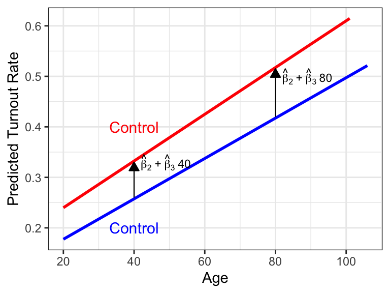

# Interpretting coefficients

$$Y_i = \alpha + \beta_1\text{age}_i + \beta_2 \text{neighbors}_i +
\beta_3 (\text{age}_i \times \text{neighbors}_i)$$

- $\hat{\alpha}$: average turnout for 0 year-olds in the control group.
- $\hat{\beta}_1$: slope of regression line for age in the control group.
- $\hat{\beta}_2$: average effect of Neighbors mailer for 0 year-olds.
- $\hat{\beta}_3$: change in the **effect** of the Neighbors mailer for a 1-year $\uparrow$ in age.
  - Effect for $x$ year-olds: $\hat{\beta}_2 + \hat{\beta}_3 x$
  - Effect for $(x+1)$ year-olds: $\hat{\beta}_2 + \hat{\beta}_3 (x+1)$
  - Change in effect: $\hat{\beta}_3$

# Interactions in R

- You can use the `:` way to create interaction terms like last time:

```r
int.fit <- lm(primary2006 ~ age + neighbors + age:neighbors, data = social.neighbor)
coef(int.fit)
```

[output not shown]

- Or you can use the `var1 * var2` shortcut, which will add both variable and their interaction:

```r
int.fit2 <- lm(primary2006 ~ age*neighbors, data = social.neighbor)
coef(int.fit2)
```

[output not shown]

# General interpretation of interactions

$$\hat{Y}_i = \hat{\alpha} + \hat{\beta}_1 X_i + \hat{\beta}_2 Z_i +
\hat{\beta}_3 X_i Z_i$$

- $\hat{\alpha}$: average turnout when $X_i$ and $Z_i$ are $0$.
  - $\hat{\beta}_1$: average change in $Y_i$ of a one-unit change in $X_i$ when $Z_i = 0$.
  - $\hat{\beta}_2$: average change in $Y_i$ of a one-unit change in $Z_i$ when $X_i = 0$.
  - $\hat{\beta}_3$: has two equivalent interpretations:
    - Change in the effect/slope of $X_i$ for a one-unit change in $Z_i$
    - Change in the effect/slope of $Z_i$ for a one-unit change in $X_i$

# Nonlinear relationships

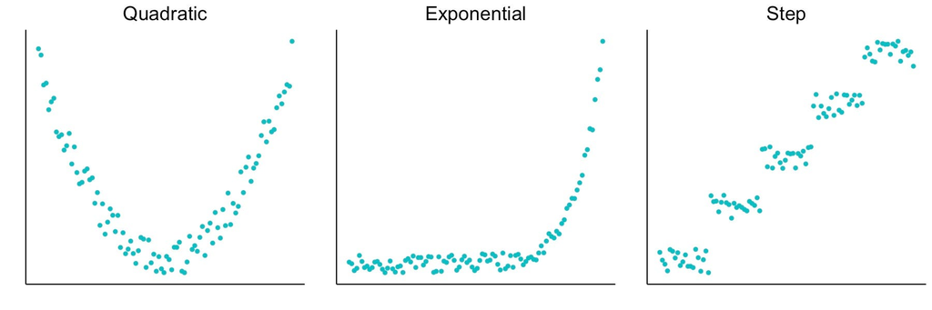

Types of Non-linear Relationships

# Linear regression are linear

$$\hat{Y}_i = \hat{\alpha} + \hat{\beta}_1 X_i$$

- Standard linear regression can only pick up **linear** relationships.
- What if the relationship between $X_i$ and $Y_i$ is nonlinear?

# Adding a squared term

- To allow for nonlinearity in age, add a squared term to the model

$$\hat{Y}_i = \hat{\alpha} + \hat{\beta}_1 \text{age}_i + \hat{\beta}_2
\text{age}_i^2$$

- We are now fitting a **parabola** to the data.
- In R, we need to wrap the squared term in `I()`:

```r
fit.sq <- lm(primary2006 ~ age + I(age^2), data = social)
coef(fit.sq)
```

```
##   (Intercept)           age      I(age^2)
## -8.168043e-02  1.227357e-02 -8.078954e-05
```

# Predicted values from lm()

- We can get predicted values out of R using the `predict()` function:

```r
predict(fit.sq, newdata = list(age = c(20, 21, 22)))
```

```
##         1         2         3
## 0.1314752 0.1404364 0.1492361
```

- Create a vector of ages to predict and save predictions:

```r
age.vals <- 20:85
age.preds <- predict(fit.sq, newdata = list(age = age.vals))
age.plot <- tibble(age.vals,age.preds)
```

- Plot the predictions:

```r
ggplot(age.plot,aes(x = age.vals, y = age.preds)) +
  geom_point(color = "blue", size = 3, shape = 1) + ylim(0.1, 0.55) +
  labs(x = "Age", y = "Predicted Turnout Rate") + theme_bw()
```

# Plotting predicted values

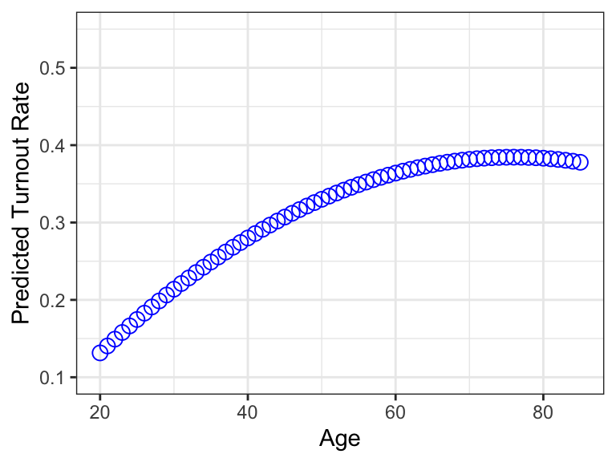

# Plotting lines instead of points:

- If you want to connect the dots in your scatterplot, you can use `geom_line()`:

```r
ggplot(age.plot, aes(x = age.vals, y = age.preds)) +
  geom_line(color = "blue", size = 1.5) +
  ylim(0.1, 0.55) +
  labs(x = "Age", y = "Predicted Turnout Rate") +
  theme_bw()
```

# Plotting predicted values

- If you want to connect the dots in your scatterplot, you can use `geom_line()`:

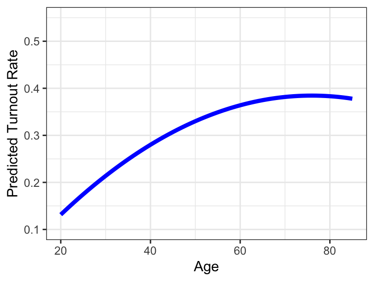

# Comparing to linear fit

- If you want to connect the dots in your scatterplot, you can use `geom_line()`:

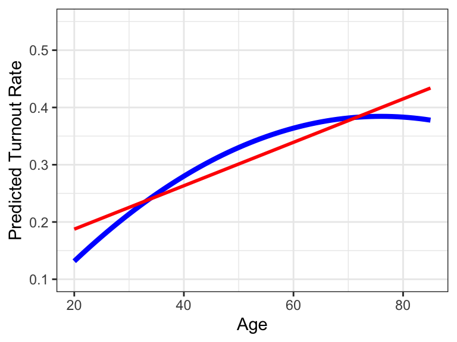

# Diagnosing nonlinearity

- One independent variable: just look at a scatterplot.
- With multiple independent variables, harder to diagnose.
- One useful tool: scatterplot of residuals versus independent variables.
- Example: let’s talk about walking and health

```r
health <- read.csv("../data/health.csv")

w.fit <- lm(weight ~  steps.lag + dayofyear, data = health)
```

# Residual plot

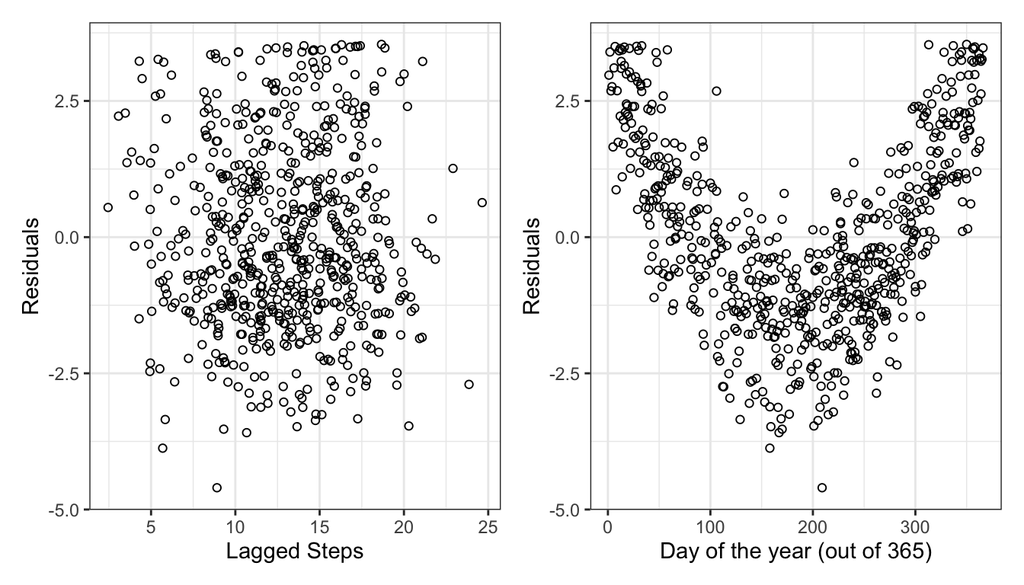

# Add a squared term for a better fit

```r
w.fit.sq <- lm(weight ~ steps.lag + dayofyear + I(dayofyear^2), data = health)
coef(w.fit.sq)
```

```
##    (Intercept)      steps.lag      dayofyear I(dayofyear^2)
##   1.749194e+02  -2.509427e-03  -5.288116e-02   1.439635e-04
```

# Residual plot, redux

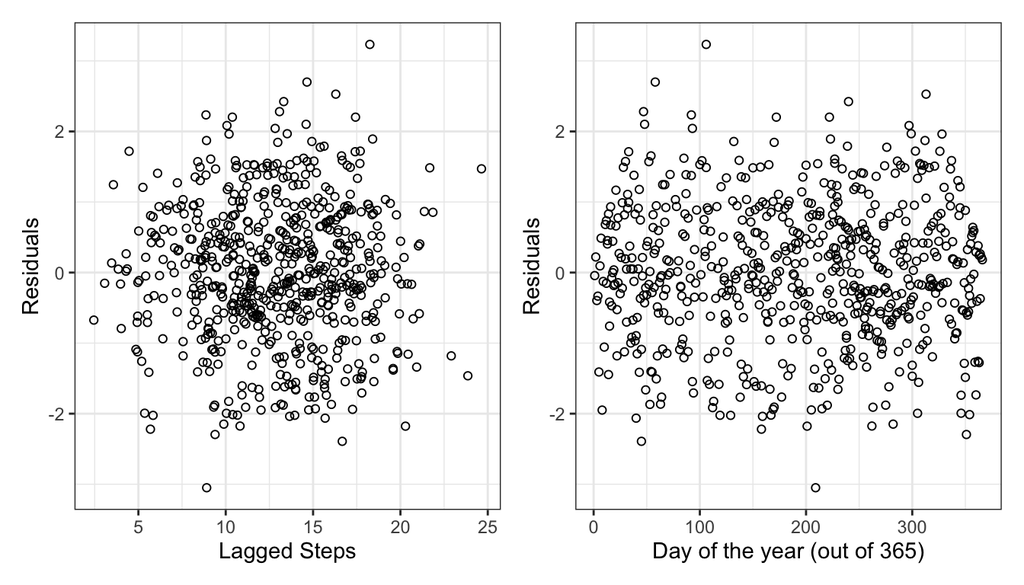